# INFSCI 2595 Final Project

Part 3D1, Classification - Resampling - GLM

Radhika Purohit

```r
knitr::opts_chunk$set(echo = TRUE)
```

```r
library(tidyverse)
library(caret)
library(tidymodels)
tidymodels_prefer()
```

```r
df <- readr::read_csv("paint_project_train_data.csv", col_names = TRUE)
dfiiiD <- df %>%
  select(-response) %>%
  mutate(outcome = ifelse(outcome == 1, 'event', 'non_event'),
         outcome = factor(outcome, levels = c('event', 'non_event')))

dfiiiD %>% glimpse()
```

```
## Rows: 835
## Columns: 7
## $ R          <dbl> 172, 26, 172, 28, 170, 175, 90, 194, 171, 122, 0, 88, 144, …
## $ G          <dbl> 58, 88, 94, 87, 66, 89, 78, 106, 68, 151, 121, 140, 82, 163…
## $ B          <dbl> 62, 151, 58, 152, 58, 65, 136, 53, 107, 59, 88, 58, 132, 50…
## $ Lightness  <chr> "dark", "dark", "dark", "dark", "dark", "dark", "dark", "da…
## $ Saturation <chr> "bright", "bright", "bright", "bright", "bright", "bright",…
## $ Hue        <dbl> 4, 31, 8, 32, 5, 6, 34, 10, 1, 21, 24, 22, 36, 16, 26, 12, …
## $ outcome    <fct> event, event, event, non_event, non_event, non_event, non_e…
```

By converting `outcome` to a factor, the unique values of the variables are “always known”:

```r
dfiiiD %>% pull(outcome) %>% levels()
```

```
## [1] "event"     "non_event"
```

However, the value counts are the same as the original encoding.

```r
dfiiiD %>% count(outcome)
```

```
## # A tibble: 2 × 2
##   outcome       n
##   <fct>     <int>
## 1 event       191
## 2 non_event   644
```

## Generalized Linear Models

**Create the blueprints for data preprocessing & feature engineering.**

```r
bp_prep_cl <- recipe(outcome ~ ., data=dfiiiD) %>%
  step_normalize(all_numeric_predictors())
  #prep(training=df_clas, retain=T) %>% bake(new_data=NULL)
```

### Predefined models

- `3D1`: All categorical and continuous inputs - linear additive features.

```r
bp_3D1 <- bp_prep_cl %>%
  step_dummy(all_nominal_predictors())
```

- `3D2`: All pairwise interactions of continuous inputs, include additive categorical features.

```r
bp_3D2 <- bp_prep_cl %>%
  step_interact(~ all_numeric_predictors():all_numeric_predictors(), sep = ":") %>%
  step_dummy(all_nominal_predictors())
```

### Custom models

- Import previous models that are referenced here.

```r
mod_3A7 <- readr::read_rds("mod_3A7.rds")
mod_3A6 <- readr::read_rds("mod_3A6.rds")
```

```r
ctrl <- trainControl(method = "cv", number = 10)
my_ctrl <- trainControl(method = 'repeatedcv', number = 10, repeats = 3)
my_metric <- "Accuracy"
```

## Resampling

### Setup

**Define the resampling scheme.**

- Use 5 fold cross-validation with 5 repeats for resampling.
- Will compare Accuracy, ROC area under curve metrics.

```r
set.seed(1324)
cv_folds <- vfold_cv(dfiiiD, v = 5, repeats = 5)
my_metrics_cl <- metric_set(accuracy, roc_auc, mn_log_loss)
glm_spec <- logistic_reg() %>% set_engine("glm")
```

**Create workflow set to fit.**

```r
glm_wset <- workflow_set(
  preproc = list(
    all_additive = bp_3D1,
    all_cont_pairwise = bp_3D2
    ),
  models = list(glm = glm_spec)
  )
```

### Execute

Note: to speed up knit, these two code blocks are set `eval=FALSE`. They can be manually executed in the rmarkdown file.

```r
tune_3D_glm <- glm_wset %>%
  workflow_map(
    fn = "fit_resamples",
    resamples = cv_folds,
    metrics = my_metrics_cl,
    control = control_resamples(save_pred = F),
    verbose = T
  )
```

```
## i 1 of 2 resampling: all_additive_glm
```

```
## ✔ 1 of 2 resampling: all_additive_glm (918ms)
```

```
## i 2 of 2 resampling: all_cont_pairwise_glm
```

```
## ✔ 2 of 2 resampling: all_cont_pairwise_glm (1.1s)
```

## Conclusions

### Performance

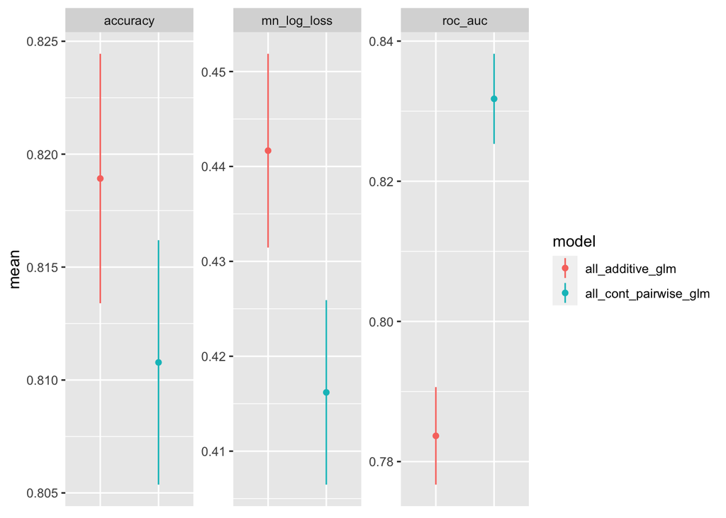

```r
tune_3D_glm %>% collect_metrics() %>%
  ggplot(aes(x=wflow_id, color=wflow_id)) +
  geom_linerange(aes(ymin=mean-std_err, ymax=mean+std_err))+
  geom_point(aes(y=mean), position = position_dodge(0.8)) +
  facet_wrap(~ .metric, scales = "free_y") +
  theme(axis.title.x=element_blank(), axis.text.x=element_blank(), axis.ticks.x=element_blank()) +
  labs(color="model")
```

### Best Model

**Finalize the workflow for the best model and retrain with resampling to save predictions.**

```r
glm_best_wflow_roc <- "all_additive_glm"

mod_3D_glm_best_wflow <- glm_wset %>%
  extract_workflow(glm_best_wflow_roc)

mod_3D_glm_best_resample <-
  mod_3D_glm_best_wflow %>%
  fit_resamples(
    cv_folds,
    metrics = my_metrics_cl,
    control = control_resamples(save_pred = T)
  )

mod_3D_glm_best_resample %>% collect_metrics() %>% select(-.config, -.estimator)
```

```
## # A tibble: 3 × 4
##   .metric      mean     n std_err
##   <chr>       <dbl> <int>   <dbl>
## 1 accuracy    0.819    25 0.00552
## 2 mn_log_loss 0.442    25 0.0102
## 3 roc_auc     0.784    25 0.00696
```

```r
mod_3D_glm_best_resample %>% readr::write_rds("mod_3D_glm_best_resample.rds")
```